# FigureYa171subgroupSurv

**Author(s)**: Shipeng Guo  
**Reviewer(s)**: Ying Ge, Junyi Shen  
**Date**: 2025-12-17

## 1 Academic Citation

If you use this code in your work or research, we kindly request that you cite our publication:

Xiaofan Lu, et al. (2025). FigureYa: A Standardized Visualization Framework for Enhancing Biomedical Data Interpretation and Research Efficiency. iMetaMed. https://doi.org/10.1002/imm3.70005

## 2 需求描述 Requirement

我们对亚组进行分析（比如说，risk signature在不同的年龄、性别、gleason评分等）的时候，区分高危和低危之后，画图把高危和低危的预测放到不同的年龄或肿瘤级别中，看看是否仍然有效。 目前只能通过手动来做，是否可以帮忙做一个续惯的流程。输入survival信息，和不同的临床亚组。

When performing subgroup analysis (for example, risk signatures for different age groups, genders, Gleason scores, etc.), after distinguishing high-risk from low-risk, we plot these predictions across different age groups or tumor grades to see if they still hold true. Currently, this can only be done manually. Could you help me create a custom workflow?

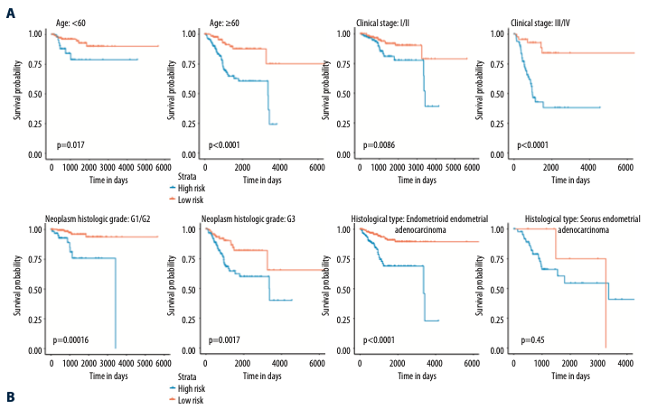

From https://www.onlinelibrary.wiley.com/doi/full/10.1002/cam4.1498

Figure 7. Subgroup analyses revealed by Kaplan-Meier survival curve. (A) Stratified survival analyses based on the clinicopathological features age, clinical stage, histological stage, and neoplasm histological grade for the 7-miRNA-based OS classifier.

## 3 应用场景 Application Scenario

本质上就是每次按条件筛选数据，然后做生存分析。

你可能还想看这篇： 8秒完成2万个基因的生存分析，人人都可以！ https://mp.weixin.qq.com/s/o4e1HzG4zPIQoGT6-7D0ug

Essentially, we filter the data by condition each time and then perform a survival analysis.

You may also want to read this article: Complete survival analysis of 20,000 genes in 8 seconds, everyone can do it! https://mp.weixin.qq.com/s/o4e1HzG4zPIQoGT6-7D0ug

## 4 环境设置 Environment Setup

```r
source("install_dependencies.R")
```

```
## Starting R package installation...
## ===========================================
##
## Installing CRAN packages...
## Installing CRAN package: age
```

```
## Installing CRAN package: gleason
```

```
## Installing CRAN package: psa
```

```
## Installing CRAN package: stage
```

```
## Package already installed: survival
## Package already installed: data.table
## Package already installed: gridtext
## Package already installed: ggtext
## Package already installed: survminer
##
## ===========================================
## Package installation completed!
## You can now run your R scripts in this directory.
```

```r
library(survival) # 生存分析 survival analysis
library(survminer) # 生存曲线绘制 survival curve plotting
Sys.setenv(LANGUAGE = "en") #显示英文报错信息 # Display English error messages
options(stringsAsFactors = FALSE) #禁止chr转成factor # Disable conversion of chr to factor
```

## 5 输入文件 Input file

easy_input.csv，包含生存数据和临床亚组信息。

easy_input.csv, contains survival data and clinical subgroup information.

```r
dd <- data.table::fread("easy_input.csv",data.table = F)
dd[1:3,]
```

```
##             Id futime fustat Risk  age gleason  psa stage
## 1 TCGA.QU.A6IM   1247      0  Low  <60     <=7 <=10 T1+T2
## 2 TCGA.HC.7075    601      0  Low >=60     <=7 <=10 T1+T2
## 3 TCGA.G9.6347   2089      0  Low  <60     <=7 <=10 T1+T2
```

```r
## 自定义颜色
## Custom colors
orange <- "#EB736B"
blue <- "#57B5AB"
```

## 6 以一个亚组为例 Take a subgroup as an example

以age>=60为例，提取数据、绘制生存曲线。 Take age>=60 as an example, extract data, and plot the survival curve.

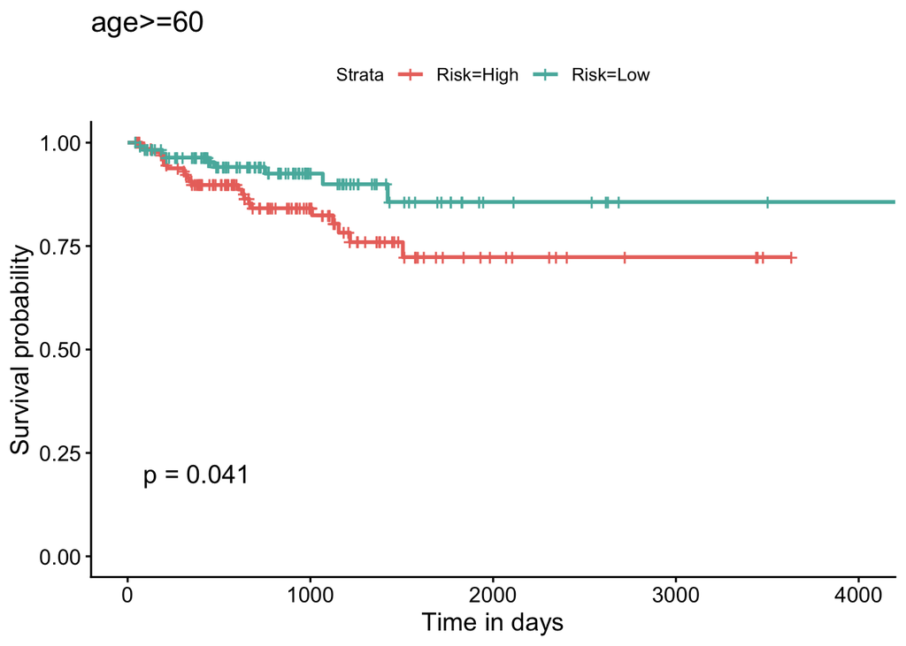

```r
## 提取数据
## Extract data
rt <- dd[dd$age==">=60",]

## 生存分析
## Survival analysis
fit <- survfit(Surv(futime, fustat) ~ Risk, data = rt)

## 作图
## Plot
ggsurvplot(fit,
           pval = TRUE,
           palette = c(orange, blue),
           title="age>=60",
           xlab="Time in days")
```

## 7 批量操作 Batch operation

本质上就是每次按条件筛选数据，然后做生存分析，重点是在筛选数据

Essentially, this involves filtering data by condition each time and then performing a survival analysis. The key is in filtering the data.

自定义函数，给一个筛选标准，直接画图。支持单次操作。

Custom function. Give a filtering criterion and plot directly. Supports single operations

```r
mysurvplot <- function(cols=cols,filter=filter){
  ## 过滤条件 ## Filter condition
  index = dd[,cols]==filter
  ## 按行过滤数据 ## Filter data by row
  rt = dd[index,]
  ## 生存分析 ## Survival analysis
  fit = survfit(Surv(futime, fustat) ~ Risk, data = rt)
  ## 计算p值 ## Calculate p-value
  x = survdiff(Surv(futime, fustat) ~ Risk, data = rt)
  pValue=1-pchisq(x$chisq,df=1)
  pValue= round(pValue,3)
  ## 作图 ## Plot
  p=ggsurvplot(fit,
             pval = pValue,
             palette = c(orange, blue),
             title=paste0(cols,filter),
             xlab="Time in days")
  return(p)
}
```

函数用法 Usage of the function

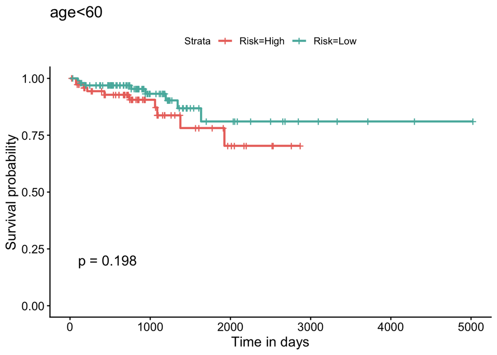

```r
# 举三个例子测试函数
# Test the function with three examples
mysurvplot("age","<60")
```

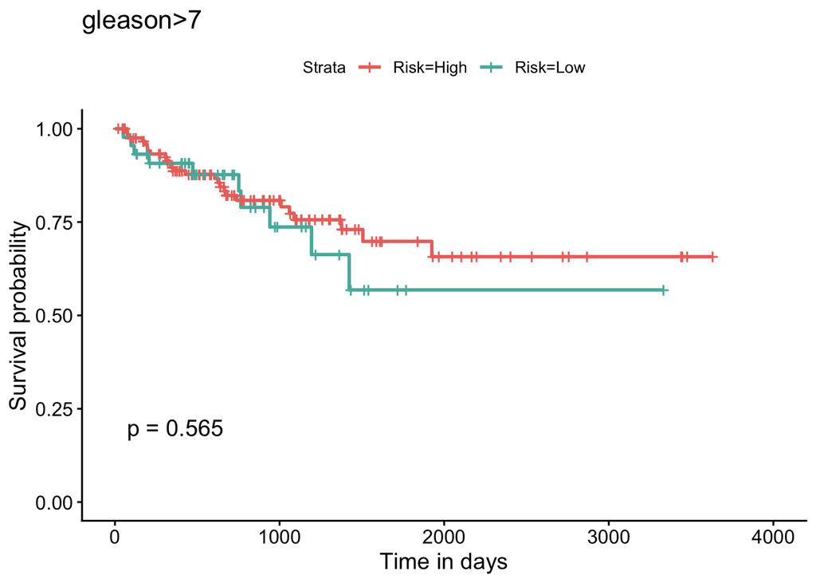

```r
mysurvplot("gleason",">7")
```

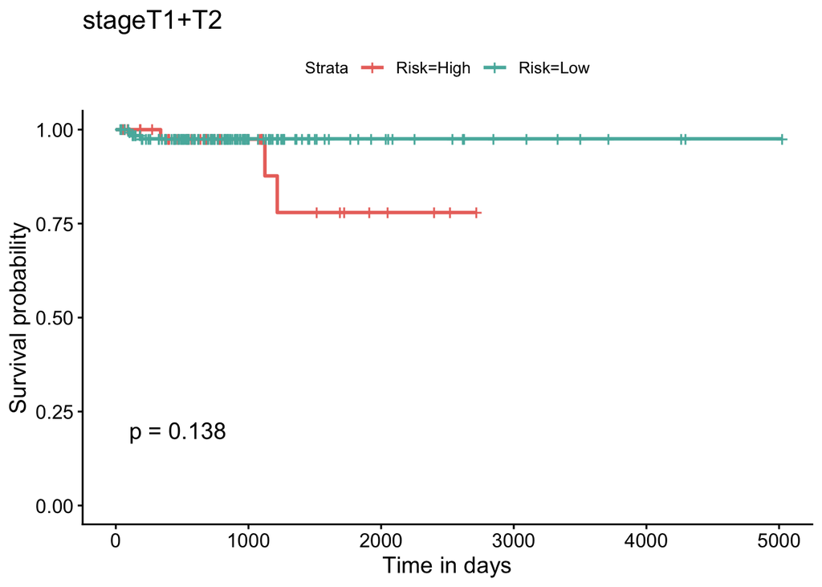

```r
mysurvplot("stage","T1+T2")
```

批量运行，把画图结果存为list

Run in batches, saving the plot results as a list

```r
# 为了方便批量操作，把筛选条件写成向量形式
# For ease of batch operation, write the filter criteria as a vector
cols <- c("age","age","gleason","gleason","psa","psa","stage","stage")
filter <- c(">=60","<60","<=7",">7","<=10",">10","T1+T2","T3+T4")

p <- list()
for ( i in 1:length(cols)) {
  p[[i]] = mysurvplot(cols[i],filter[i])
}
```

拼图 Merge Graph

[figure not shown]

```r
## arrange_ggsurvplots来自于survminer包，用于排列结果
## print = T，直接显示
## arrange_ggsurvplots comes from the survminer package and is used to arrange the results.
## print = T, direct display
arrange_ggsurvplots(p, print = T,
                    ncol = 4, nrow = 2,
                    labels=LETTERS[1:8])
```

```r
## 或者print = F, 然后保存到PDF文件
## Or print = F, then save to PDF file
res <- arrange_ggsurvplots(p, print = F,
                           ncol = 4, nrow = 2)
ggsave("subgroupSurv.pdf", res, width = 20, height = 10)
```